# Reservoir Alignment: Multi-Context Reconciliation

## Narrative

Authors: **Mike Johnson** + Lynker Spatial Team

Accurate reservoir locations are essential for hydrologic modeling because reservoirs alter the natural flow regime by **storing, releasing, and redistributing** water across space and time. These operations directly influence downstream streamflow, flood peaks, drought severity, water availability, and ecosystem conditions. Today’s NWM only accounts for ~500 reservoirs across CONUS, which is incomplete for many forecasting and planning applications. To extend the scope of reservoir locations, data from other resources is needed.

The National Inventory of Dams (NID) provides broad **coverage** but variable **location** quality (on-reservoir, on-flowline, generalized, sometimes wrong). Even small positional errors can misconnect a dam/reservoir to the wrong flowline or waterbody, degrading routing of inflows/outflows and reducing model skill for discharge, storage, and evapotranspiration—undermining flood forecasting, drought planning, and environmental flow assessments.

Other datasets often have better **locations** but are incomplete or inconsistent in other ways particularly with spatial coverage. Critically, each dataset also opens doors for **data assimilation**, **parameterization**, and **ML training** on historic time series. By grounding our reference reservoirs with precise geographic **contexts** and aligning to a shared hydrographic fabric, we get regulated flow representation that better reflects the coupled human–natural water cycle and is a boon to community efforts like those at **Geoconnex** and as **NOAA/NWS POIs** in the NWM.

Our goal is to build a **harmonized set of reference reservoirs (proxied by dams)** that are geospatially consistent with the hydrofabric used in USGS and NOAA/NWS modeling. We treat NID as the **global set** to validate and enrich, assign stable synthetic IDs (`dam_id = "ls-*"`), and use multiple contexts to correct locations and enhance attributes.

**Strategy (evidence aggregation):**

- build candidate pairs via spatial proximity within tuned **per-context radii**,
- compute **name similarity** (Jaro–Winkler) from cleaned strings
- **rank** contexts by reliability and derived evidence,
- select a **best realization** per dam, with diagnostics.

**Per-dam output:** A chosen realization (context + ID), snap distance (m), name similarity, number of supporting contexts, and offset from the original NID point.

- **NID (cleaned, EPSG:5070, synthetic IDs `dam_id = "ls-*"`).** Baseline catalog (USACE). High inclusivity; variable positional accuracy. Synthetic IDs provide stable tracking.
- **Lynker Spatial hydrofabric flowlines (`ref_fab_fp`) + waterbodies (`ref_fab_wb`).** National hydrographic backbone (v2.3). Consistent topology for flowlines and waterbodies aligned to modeling needs.
- **OpenStreetMap (OSM): water polygons, water lines, dam lines.** Volunteer geographic data adding local detail; quality and coverage vary regionally.
- **GNIS.** USGS naming authority for natural/cultural features (dams, lakes, reservoirs), used for robust naming comparisons.
- **ResOpsUS.** Reservoir operations and attributes useful for modeling and water management.
- **HILARRI.** Curated links among NID (2024), GRanD (v1.3), and EHA (2024), connecting dams, reservoirs, and hydropower plants (ORNL/DOE).
- **GOODD.** Global dam compilation (>38k) with attributes supporting large-scale analyses.
- **NWM (optionally re-linked to WB IDs).** NOAA’s hydrologic modeling system. Reservoir POIs can be re-indexed to hydrofabric WBs to improve geometric alignment.

## **Bring Your Own.**: The method is extensible so that anyone can add a dataset by specifying a unique ID, search radius, and rank weight; it will be harmonized with the principal data resources.

[output not shown]

## Process Overview

### Tiling

CONUS is divided into ~**100 km** cells. We process only tiles that intersect dams. Each tile runs independently (bounded memory; smaller candidate pools). Per-tile results are written to RDS; a final pass stitches tiles, resolving overlaps by preferring **more supporting contexts (`n`)** then **closer snaps**.

[figure not shown]

### NID as Core Context

The **NID** defines the **global set** we validate, supplement, and standardize. Because NID IDs can be duplicated and locations imprecise, we assign **stable synthetic IDs** (`dam_id = ls-*`) and treat NID like any other context in scoring—*but* privileged as the anchor. Outputs retain NID identifiers while updated coordinates, names, and attributes can be adopted from the **best realization** across contexts. This preserves continuity with the most complete inventory while systematically improving accuracy via GNIS names, GOODD’s footprint, hydrofabric topology, and OSM detail—producing features that are **Geoconnex-ready** and compatible with **NWS POIs**.

### Context Definition

A **context** is an external dataset/layer (e.g., `gnis`, `goodd`, `ref_fab_fp`, `osm_ww_poly`) against which NID dams are compared. For each dam and context, we:

1. generate **candidate pairs** within a tuned **search radius**,
2. compute **snap distance** and **name similarity (JW)**, and
3. **filter/rank** to a single best match per (dam, context).

Two **derived** contexts are also created by intersecting waterbodies and flowlines in each data family:

- `ref_int`: intersections of **ref_fab_wb × ref_fab_fp**
- `osm_int`: intersections of **osm_ww_poly × osm_ww_lines**

These provide strong geometry/topology anchors.

### Ranking Policy

- **0 – Intersection evidence:** `ref_int`, `osm_int` (geometry + topology; strongest).
- **1 – Curated/named:** `gnis`, `resops`, `goodd`, `osm_dam_lines`, `hillari`.
- **2 – Direct/core geometries:** `osm_ww_poly`, `osm_ww_lines`, `ref_fab_fp`, `ref_fab_wb`, `nwm` (re-linked), `nid`.
- **Tributary penalty:** if `river` implies TR/OS/TRIB, add **+5** to rank. Within any tier, **smaller snap** and **smaller JW** win.

### Process

1. **Per tile**
   1. Load dams (NID) and clip contexts.
   2. Build **representative points** per context: points (identity), lines (midpoints/endpoints), polygons (point-on-surface).
   3. Generate candidates via **`st_is_within_distance`** (per-context radius) with a **KNN fallback** gated by the same radius.
   4. Score (snap distance, JW), apply tributary penalty; **reduce to best per (dam, context)**.
   5. Build a **wide table** of IDs (one column per context), select **best realization** per dam, compute **QA** (offset from NID), and distance to flowpath.
   6. Write **tile RDS** and append a **manifest row**.

### Contexts: Search Distance & Rank Priority

| Context | Search Distance (m) | Rank | Group | Notes |
| --- | --- | --- | --- | --- |
| ref_int | 2000 | 0 | Anchors / Derived | Intersections of ref_fab_wb × ref_fab_fp; highest-confidence geometry. |
| osm_int | 2000 | 0 | Anchors / Derived | Intersections of osm_ww_poly × osm_ww_lines; strong topology signal. |
| gnis | 2000 | 1 | Curated / Named | USGS names; authoritative nomenclature, variable location quality. |
| resops | 2000 | 1 | Curated / Named | Reservoir ops/attributes useful for modeling. |
| osm_dam_lines | 1500 | 1 | Curated / Named | OSM dam features; coverage varies. |
| hillari | 2000 | 1 | Curated / Named | Links dams–reservoirs–plants (ORNL/DOE). |
| goodd | 2000 | 1 | Curated / Named | Global dam footprint/attributes. |
| osm_ww_lines | 1500 | 2 | Direct / Network | Dense/noisy; short radius reduces false hits. |
| osm_ww_poly | 1500 | 2 | Direct / Network | Strong geometric anchors for reservoirs. |
| ref_fab_fp | 1500 | 2 | Direct / Fabric | Topologically consistent flowlines. |
| ref_fab_wb | 2000 | 2 | Direct / Fabric | Waterbodies as spatial anchors. |
| nwm | 2000 | 2 | Direct / POIs | Often mislocated; improved when re-indexed to WBs. |
| nid | 2000 | 2 | Core Dataset | Baseline set for validation & enrichment; stable synthetic IDs. |

## Risks & Mitigations

[output not shown]

## Appendix: Version 1.0 plots

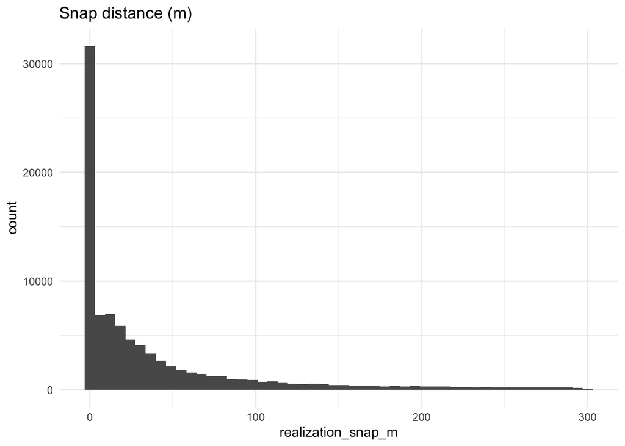

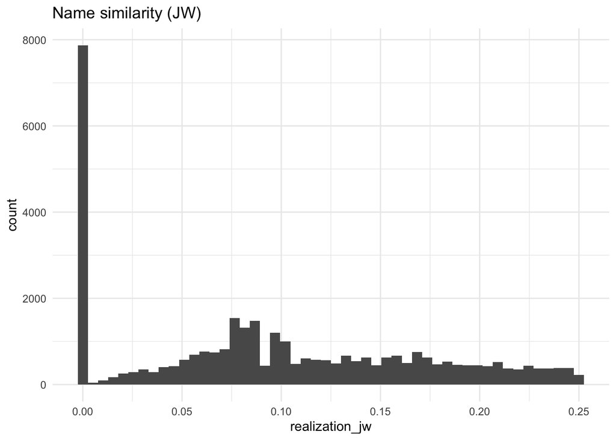

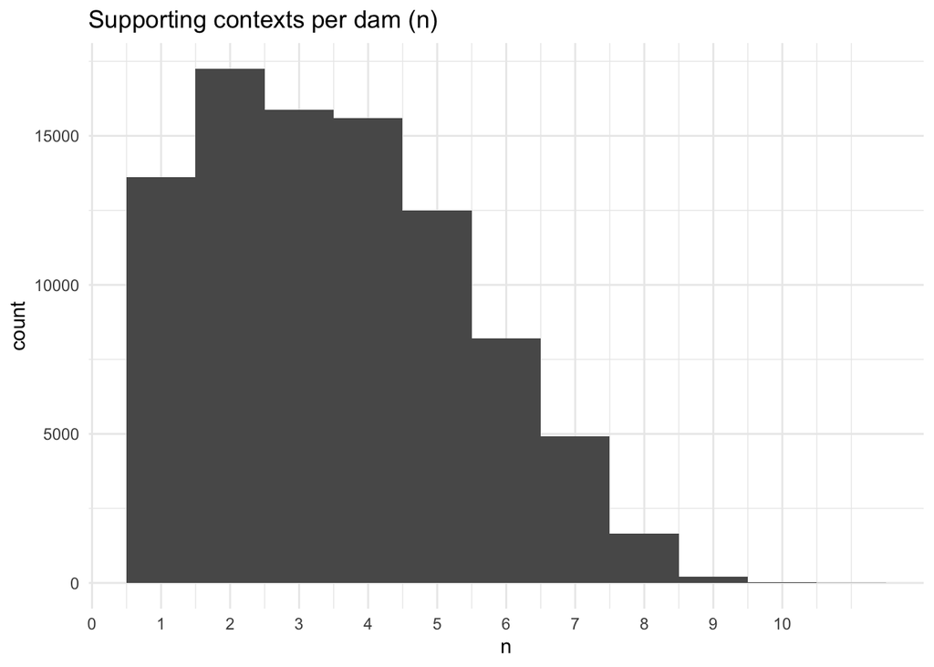

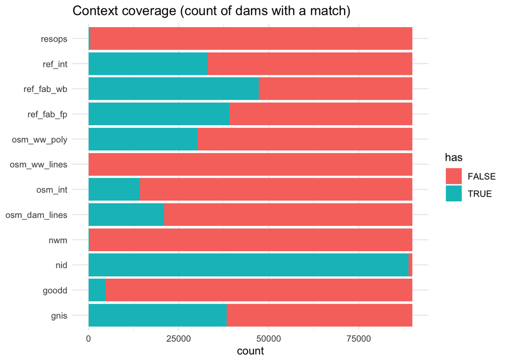

## Use:

- To use this repo, all data is stored wit the exception of OSM. All data - including OSM - can be downloaded with the direction in the `data/data_prep.R`.
- Run `workflow/01_process_tiles.R` If new resources are added, be sure to include them in the ingest as well as provide a rank and radius
- `02_stich.R` stitches the tiles together and adds preliminary info
- `03_ops.R` adds reservoir parameters needd for RFC-DA in the NWM using a mix of traits.
- If you want to recreate the webmap, run the make file in scripts/tiles using the latest gpkg. Output can be viewed with `pnpm dev --strictPort --port 8000`